# 擷取網路資料 (I)

Web API、JSON、`httr`

2019-11-21 (W11)

## HTTP

- HTTP 是網路上，電腦與電腦 (伺服器) 之間進行溝通時，所遵循的一套規則。當你在瀏覽器當中輸入一個網址 (URL) 時，你的瀏覽器會幫你向位於該 URL 的伺服器發出一個 **HTTP request**。伺服器收到這個 HTTP request 之後，會解讀它，並依據解讀的結果，向你的電腦送出 **HTTP response**。若一切正常運作，HTTP response 應會包含你想要的內容 (e.g. 某個網頁)。你的瀏覽器在接收到 HTTP response 之後，會解讀它並將其所包含的內容 (e.g. HTML) (經處理後) 呈現在螢幕上。

[figure not shown]

Hypertext Transfer Protocol (HTTP)

- 通常，我們輸入網址後所收到的內容是 HTML 格式，因此我們在瀏覽器解讀 HTML 後，會在螢幕呈現出一個 (漂亮的) 網頁。但不一定所有網址都會回傳 HTML 的格式，有時候會是其它格式，例如 JSON 格式 (https://api.exchangeratesapi.io/latest) 或是 `text/plain` (https://rlads2019.github.io/hw8/idioms.txt)。這時，瀏覽器上就會呈現出純文字的樣子:

[figure not shown]

JSON shown on Browser

- 伺服器回傳 JSON 格式不是為了 (直接) 給人看的，而是為了**方便程式與電腦處理**。換言之，位在這個 URL 的伺服器希望使用者**透過程式與自己互動**，因此它不提供一個漂亮的界面 (i.e. 網頁)，而是提供一個 [Web API](https://en.wikipedia.org/wiki/Web_API)，讓使用者可以透過程式語言直接取得乾淨、結構化的資料。

## URL 結構

- Web API 的設計常是透過讓使用者在 URL 加上一些訊息 (query string)，藉此得知使用者想取得哪些資料。
  - 例如，[Foreign exchange rates API](https://exchangeratesapi.io) 透過使用者在 URL 之後加上的 `start_at=<date>` 以及 `end_at=<date>`，判斷回傳的資料所需包含的時間範圍: `https://api.exchangeratesapi.io/history?start_at=2018-01-01&end_at=2018-09-01`
- URL 當中的 query string 具有一些特殊的結構。query string 讓使用者可以提供一或多個 key-value pairs (需看 API 說明文件)。例如，上方例子中的 `start_at` 與 `end_at` 即為 key-value pairs 中的 key，在 key 與 value 之間則用 `=` 分隔。詳見下圖的 URL 結構。

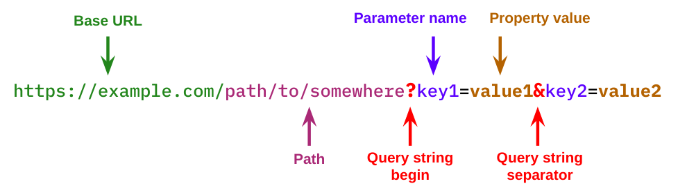

URL 結構

## `httr`

[figure not shown]

- 我們通常是透過瀏覽器與網路上的其它電腦 (伺服器) 互動 (i.e. 透過瀏覽器發出/接收 HTTP request/response)。但我們也可以透過 R 做到這件事 — 套件 `httr` 即提供一些函數方便在 R 裡面處理 HTTP request/response。
- 下方，我們使用 `httr::GET()` 向 `https://api.exchangeratesapi.io/history?start_at=2018-01-01&end_at=2019-02-01` 發出 HTTP request，以取得 `2018-01-01` 至 `2019-02-01` 之間的匯率資料:

  ```r
  library(httr)

  req <- GET('https://api.exchangeratesapi.io/',
             path = 'history',
             query = list(start_at = "2018-01-01",
                          end_at = "2019-02-01"))
  ```

  - 雖然我們可以將**整個 URL** 以字串的形式寫在 `httr::GET()` 的第一個 argument，但我們通常會將 URL 拆開成 **base URL**, **path** 以及 **query string** 這三個部份 (見上 URL 結構)，再透過 `httr::GET()` 所提供的一些 argument 組出完整的 URL[^1]:
    - `url` (first arg.): URL 中的 base URL，即上圖綠色部份 `https://api.exchangeratesapi.io/`
    - `path`: URL 中的 path，即上圖紫色部份 `history`
    - `query`: URL 中的 query string。在 `httr::GET()` 中，query 是以 `list` 的資料結構提供。上方的 URL 因為有兩個 key-value pairs，所以 `query` 這個 argument 也由兩個元素 (皆有 name) 組成。
- `httr::GET()` 會將 HTTP request 以及接收到的 HTTP response 轉換成 R 的物件。例如，`req[["url"]]` 可以取得 HTTP request 目的地 URL，`req[["status_code"]]` 則可以看到伺服器回傳 (HTTP response) 的訊息 (200 代表 request 成功，4** 通常代表失敗)：

  ```r
  req[["url"]]
  ```

  ```
  #> [1] "https://api.exchangeratesapi.io/history?start_at=2018-01-01&end_at=2019-02-01"
  ```

  ```r
  req[["status_code"]]
  ```

  ```
  #> [1] 200
  ```

- 若要取得 HTTP response 的內容，可使用 `httr::content()`。若 response 的內容格式是 JSON，XML 或 HTML，`httr::content()` 會自動將其轉換成 R 的物件，若不想自動進行這件事，可加入 `as = "text"` 這個 argument：

  ```r
  content(req)
  ```

  ```
  #> $rates
  #> $rates$`2019-01-22`
  #> $rates$`2019-01-22`$CAD
  #> [1] 1.5128
  #>
  #> $rates$`2019-01-22`$HKD
  #> [1] 8.909
  #>
  #> $rates$`2019-01-22`$ISK
  #> [1] 137
  #>
  #> $rates$`2019-01-22`$PHP
  #> [1] 60.056
  #>
  #> $rates$`2019-01-22`$DKK
  #> [1] 7.4669
  #>
  #> $rates$`2019-01-22`$HUF
  #> [1] 317.98
  #>
  #> $rates$`2019-01-22`$CZK
  #> [1] 25.612
  #>
  #> $rates$`2019-01-22`$AUD
  #> [1] 1.5923
  #>
  #> $rates$`2019-01-22`$RON
  #> [1] 4.7292
  #>
  #> $rates$`2019-01-22`$SEK
  #> [1] 10.2538
  #>
  #> $rates$`2019-01-22`$IDR
  #> [1] 16160.15
  #>
  #> $rates$`2019-01-22`$INR
  #> [1] 81.046
  #>
  #> $rates$`2019-01-22`$BRL
  #> [1] 4.2622
  ```

  [output cut: 27133 more lines]

  ```
  #> [1] 1274.86
  #>
  #> $rates$`2018-05-21`$MYR
  #> [1] 4.6801
  #>
  #>
  #>
  #> $start_at
  #> [1] "2018-01-01"
  #>
  #> $base
  #> [1] "EUR"
  #>
  #> $end_at
  #> [1] "2019-02-01"
  ```

  ```r
  cat(content(req, as = "text"))
  ```

  ```
  #> {"rates":{"2019-01-22":{"CAD":1.5128,"HKD":8.909,"ISK":137.0,"PHP":60.056,"DKK":7.4669,"HUF":317.98,"CZK":25.612,"AUD":1.5923,"RON":4.7292,"SEK":10.2538,"IDR":16160.15,"INR":81.046,"BRL":4.2622,"RUB":75.4433,"HRK":7.4265,"JPY":124.25,"THB":36.128,"CHF":1.1326,"SGD":1.5452,"PLN":4.2827,"BGN":1.955…
  ```

#### HTTTP request methods

HTTP request 有許多「不同」的種類，稱為 [request methods](https://developer.mozilla.org/en-US/docs/Web/HTTP/Methods)。最常見的一種即是 `GET method`，例如在網頁輸入 URL 或是剛剛使用的 `httr::GET()`， 都是在向伺服器發出 `GET` request。`GET` request 的目的是向伺服器**取得**資料。另一種常見的 request method 是 `POST`。`POST` request 的目的是向伺服器**提交**資料，常見的例子是「帳號登入」與「填寫表單」。關於 HTTP request methods 可見 https://developer.mozilla.org/en-US/docs/Web/HTTP/Methods。

## JSON

- JSON 是一種純文字格式，跟 `.csv` 一樣是用來記錄結構化資訊的一種格式。但 JSON 可以記錄結構複雜許多的資料，因為它可以具有階層 (巢狀) 結構。
- JSON 所記錄的資料，結構上與 R 的 list 非常接近。下圖左邊的 R 程式碼所建立出的 list，其表徵的資料結構，等價於右方的 JSON:

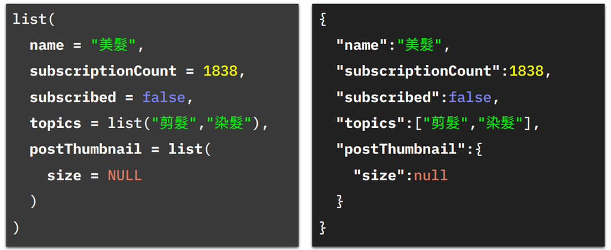

  - 在 R 裡面，可以使用 `jsonlite` 套件協助處理 JSON。例如，`jsonlite::fromJSON()` 可將符合 JSON 格式的字串轉換成 R 的 list (反之，使用 `jsonlite::toJSON()`):

    ```r
    json_str1 = '{
      "name":"美髮",
      "subscriptionCount":1838,
      "subscribed":false,
      "topics":["剪髮","染髮","洗髮"],
      "postThumbnail":{
        "size":null
      }
    }'

    jsonlite::fromJSON(json_str1, simplifyVector = F)
    ```

    ```
    #> $name
    #> [1] "美髮"
    #>
    #> $subscriptionCount
    #> [1] 1838
    #>
    #> $subscribed
    #> [1] FALSE
    #>
    #> $topics
    #> $topics[[1]]
    #> [1] "剪髮"
    #>
    #> $topics[[2]]
    #> [1] "染髮"
    #>
    #> $topics[[3]]
    #> [1] "洗髮"
    #>
    #>
    #> $postThumbnail
    #> $postThumbnail$size
    #> NULL
    ```

#### Format

- 通常，JSON 格式是以 `{` 開頭，以 `}` 結尾 (有時是 `[` 與 `]`)。在 `{` 與 `}` 之間，是由一個個 `key:value` pair 所組成，每個 key-value pair 之間以 `,` 分隔。key 的形式一定是字串，而 value 可為：
  - 字串、數值、布林值、`null`
  - 或是一個以 `{}` 包裹的 key-value pairs (i.e., 可具有巢狀結構)
- 在 JSON 格式裡，`{}` 之內的 key-value pair 並無次序關係。若需要表徵先後次序，需使用 array: `[]`。在 `[]` 中，可以放入任意數量以及各個類別的資料 (彼此以 `,` 分隔)，例如：

  ```json
  {
    "id":"rlads2019",
    "array1":[1.1,"a string",false],
    "array2":[2,{"id":1234},null]
  }
  ```

[^1]: 有時候，我們會需要系統性改變 URL 的某部份 (e.g., 想取得**每年** 1/1 至 2/1 的資料) 以取得所需資料。這時，若不使用 `httr::GET()` 所提供的 `path` 與 `query` 等 argument，就需自己另外以 `paste0()` 等函數製造 URL。這會造成程式變得比較龐大且複雜。